# Chapter 2 - Introduction to R for Bioinformatics

Sasha Ajay Malkani

2025-12-15

## 1. Getting Started with R - Downloading R

[The comprehensive R Archive Network (CRAN)](https://cran.r-project.org/)

## 2. Getting started with R Studio - Download R studio

[RStudio website](https://www.rstudio.com/products/rstudio/download/)

## 3. Assign values to variables

```r
my_variable <- 42
my_variable
```

```
## [1] 42
```

## 4. Data Types - Several Types

- **Vectors** - Basic data structure representing a sequence of elements
- **Data Frames** - 2-Dimensional structure akin to a table, suitable for storing data sets
- **Lists** - Collections of items that can be of different types
- **Functions** - Utilize built-in functions to perform operations

### 4. A. Functions - Calculate a mean of a vector

```r
mean_value <- mean(c(1, 2, 3, 4, 5))
mean_value
```

```
## [1] 3
```

## 5. Data Manipulation

Data pre-processing is critical in bioinformatics for accurate analysis. The **“dplyr”** package part of the **“tidyverse”** offers powerful tools for data manipulation

### 5. A. Reading Data using R functions - CSV file

```r
data <- read.csv("Literature search - complete set.csv")
head(data, n=1)
```

```
##       PMID
## 1 28692646
##                                                                                                    Title
## 1 Biomarkers for predicting type 2 diabetes development-Can metabolomics improve on existing biomarkers?
##                                                                             Authors
## 1 Savolainen O, Fagerberg B, Vendelbo Lind M, Sandberg AS, Ross AB, Bergstr\xf6m G.
##                                                               Keywords
## 1 glucose, insulin, adiponectin, lipids, carbohydrates, uric acid, T2D
##   Review_No
## 1         1
##                                                                                 Journal_Book
## 1 PLoS One. 2017 Jul 10;12(7):e0177738. doi: 10.1371/journal.pone.0177738. eCollection 2017.
##   Publication_Year Create_Date      PMCID NIHMS_ID                  DOI
## 1             2017  11/07/2017 PMC6566263          10.3390/ijms20102467
##                                                                                                                                                                           Research_Question
## 1 Aim:\xa0The aim was to determine if metabolomics could be used to build a predictive model for type 2 diabetes (T2D) risk that would improve prediction of T2D over current risk markers.
##                                                                                                                                                                                                                                                                                                          …
## 1 Methods:\xa0Gas chromatography-tandem mass spectrometry metabolomics was used in a nested case-control study based on a screening sample of 64-year-old Caucasian women (n = 629). Candidate metabolic markers of T2D were identified in plasma obtained at baseline and the power to predict diabetes …
##   no_of_participants selection_of_participants Duration_of_study
## 1                 NA                        NA                NA
##                                                                                                                                                                                                                                                                                                          …
## 1 Results:\xa0Established markers of T2D (impaired fasting glucose, impaired glucose tolerance, insulin resistance (HOMA), smoking, serum adiponectin)) alone, and in combination with metabolomics had the largest areas under the curve (AUC) (0.794 (95% confidence interval [0.738-0.850]) and 0.808 …
##                                                                                                                                                                                                                                                                                                          …
## 1 Conclusions: Established measures of T2D risk remain the best predictor of T2D risk in this population. Additional markers detected using metabolomics are likely related to these measures as they did not enhance the overall prediction in a combined model.                 The study established a…
##                                                                                                                                                                                                                                                                                                          …
## 1 MAIN FINDINGS =>  4 metabolites => galacticol, mannose, galactose + 2-hydroxybutyric acid new predictors of T2D. Established measures of T2D risk remain the best predictor of T2D risk in this population. Additional markers detected using metabolomics are likely related to these measures as they…
##   Q3_Findings Q4_Findings Q5_Findings Q6_Findings Q7_Findings Q8_Findings
## 1
```

### 5. B. Reading Data using R functions - Excel file

```r
# install.packages("readxl")
library(readxl)
data1 <- read_excel("Literature search - complete set.xlsx")
head(data1, n=1)
```

```
## # A tibble: 1 × 25
##       PMID Title        Authors Keywords Review_No Journal_Book Publication_Year
##      <dbl> <chr>        <chr>   <chr>        <dbl> <chr>                   <dbl>
## 1 28692646 Biomarkers … Savola… glucose…         1 PLoS One. 2…             2017
## # ℹ 18 more variables: Create_Date <dttm>, PMCID <chr>, NIHMS_ID <chr>,
## #   DOI <chr>, Research_Question <chr>, Design_Method <chr>,
## #   no_of_participants <lgl>, selection_of_participants <lgl>,
## #   Duration_of_study <lgl>, Q1_findings <chr>, Q2_findings <chr>,
## #   Future_Research <chr>, Q3_Findings <chr>, Q4_Findings <chr>,
## #   Q5_Findings <chr>, Q6_Findings <chr>, Q7_Findings <chr>, Q8_Findings <chr>
```

### 5. C. Data Cleaning

Involves handling missing values, filtering data sets and tranforming variables. Key functions in “dplyr” include;

- **filter()** - Select rows based on conditions
- **select()** - Choose specific columns
- **mutate()** - Create new variables or modify existing ones.

#### 5. C. I. Load Libraries

```r
library(devtools)
library(Biobase)
library(org.Hs.eg.db)
library(DBI)
library(AnnotationDbi)
library(BiocGenerics)
```

#### 5. C. II. Load in data from a connection

```r
con =url("http://bowtie-bio.sourceforge.net/recount/ExpressionSets/bottomly_eset.RData")
load(file=con)
close(con)
ls()
```

```
## [1] "bottomly.eset" "con"           "data"          "data1"
## [5] "mean_value"    "my_variable"
```

```r
bot = bottomly.eset
bot
```

```
## ExpressionSet (storageMode: lockedEnvironment)
## assayData: 36536 features, 21 samples
##   element names: exprs
## protocolData: none
## phenoData
##   sampleNames: SRX033480 SRX033488 ... SRX033494 (21 total)
##   varLabels: sample.id num.tech.reps ... lane.number (5 total)
##   varMetadata: labelDescription
## featureData
##   featureNames: ENSMUSG00000000001 ENSMUSG00000000003 ...
##     ENSMUSG00000090268 (36536 total)
##   fvarLabels: gene
##   fvarMetadata: labelDescription
## experimentData: use 'experimentData(object)'
## Annotation:
```

```r
pdata_bot=pData(bot)
head(pdata_bot)
```

```
##           sample.id num.tech.reps   strain experiment.number lane.number
## SRX033480 SRX033480             1 C57BL/6J                 6           1
## SRX033488 SRX033488             1 C57BL/6J                 7           1
## SRX033481 SRX033481             1 C57BL/6J                 6           2
## SRX033489 SRX033489             1 C57BL/6J                 7           2
## SRX033482 SRX033482             1 C57BL/6J                 6           3
## SRX033490 SRX033490             1 C57BL/6J                 7           3
```

```r
fdata_bot = featureData(bot)
head(fdata_bot)
```

```
## An object of class 'AnnotatedDataFrame'
##   featureNames: ENSMUSG00000000001 ENSMUSG00000000003 ...
##     ENSMUSG00000000049 (6 total)
##   varLabels: gene
##   varMetadata: labelDescription
```

```r
edata = exprs(bot)
head(edata, n=1)
```

```
##                    SRX033480 SRX033488 SRX033481 SRX033489 SRX033482 SRX033490
## ENSMUSG00000000001       369       744       287       769       348       803
##                    SRX033483 SRX033476 SRX033478 SRX033479 SRX033472 SRX033473
## ENSMUSG00000000001       433       469       585       321       301       461
##                    SRX033474 SRX033475 SRX033491 SRX033484 SRX033492 SRX033485
## ENSMUSG00000000001       309       374       781       555       820       294
##                    SRX033493 SRX033486 SRX033494
## ENSMUSG00000000001       758       419       857
```

#### 5. C. III. Load Libraries

```r
library(tidyverse)
```

```
## ✖ lubridate::%within%() masks IRanges::%within%()
## ✖ lubridate::second<-() masks S4Vectors::second<-()
```

```r
library(dplyr)
library(tibble)
```

#### 5. C. IV. Change expression set to a data frame

```r
edata1 = as.data.frame(edata)
edata2 = as_tibble(edata)
edata3 = data.frame(edata)
```

#### 5. C. V. Filter out data for NA’s and Mutate data

```r
clean_data <- edata1 %>% filter(!is.na(edata1)[,1] & !is.na(edata1)[,2] &
                                !is.na(edata1)[,3] & !is.na(edata1)[,4]) %>% mutate(
                                  log_SRX033480 = log(edata1[,1] + 1)) %>% mutate(
                                  log_SRX033488 = log(edata1[,2] + 1)) %>% mutate(
                                  log_SRX033481 = log(edata1[,3] + 1)) %>% mutate(
                                  log_SRX033489 = log(edata1[,4] + 1))

head(clean_data, n=1)
```

```
##                    SRX033480 SRX033488 SRX033481 SRX033489 SRX033482 SRX033490
## ENSMUSG00000000001       369       744       287       769       348       803
##                    SRX033483 SRX033476 SRX033478 SRX033479 SRX033472 SRX033473
## ENSMUSG00000000001       433       469       585       321       301       461
##                    SRX033474 SRX033475 SRX033491 SRX033484 SRX033492 SRX033485
## ENSMUSG00000000001       309       374       781       555       820       294
##                    SRX033493 SRX033486 SRX033494 log_SRX033480 log_SRX033488
## ENSMUSG00000000001       758       419       857      5.913503      6.613384
##                    log_SRX033481 log_SRX033489
## ENSMUSG00000000001       5.66296      6.646391
```

## 6. Data Summarization

```r
summary_data <- clean_data %>% group_by(fdata_bot@data) %>% summarize(
  mean_log_SRX033480 = mean(log_SRX033480),
  mean_log_SRX033488 = mean(log_SRX033488),
  mean_log_SRX033481 = mean(log_SRX033481),
  mean_log_SRX033489 = mean(log_SRX033489))

head(summary_data)
```

```
## # A tibble: 6 × 5
##   gene               mean_log_SRX033480 mean_log_SRX033488 mean_log_SRX033481
##   <fct>                           <dbl>              <dbl>              <dbl>
## 1 ENSMUSG00000000001               5.91              6.61               5.66
## 2 ENSMUSG00000000003               0                 0                  0
## 3 ENSMUSG00000000028               0                 0.693              0
## 4 ENSMUSG00000000031               0                 0                  0
## 5 ENSMUSG00000000037               0                 0.693              0.693
## 6 ENSMUSG00000000049               0                 0.693              0
## # ℹ 1 more variable: mean_log_SRX033489 <dbl>
```

## 7. Data Visualization

[figure not shown]

```r
library(ggplot2)

ggplot(clean_data[,22:25], aes(x = clean_data[,22], y = clean_data[,25])) + geom_point() +
  labs(title = "Gene Expression of sample log_SRX033480 vs log_SRX033480",
       x = "Gene Expression sample log_SRX033480", y = "Gene Expression sample log_SRX033480")
```

## 8. Advanced Visualization - Heat map

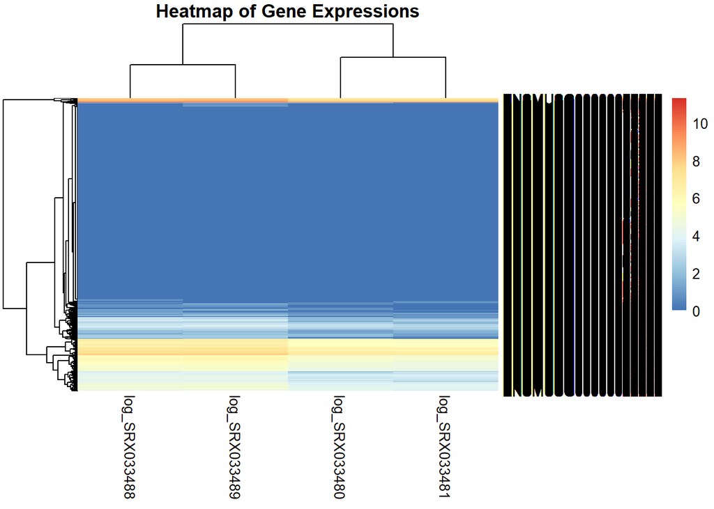

```r
install.packages("pheatmap", repos = "http://cran.us.r-project.org")
library(pheatmap)
pheatmap(as.matrix(clean_data[,22:25]), cluster_rows = TRUE, cluster_cols = TRUE,
         main = "Heatmap of Gene Expressions")
```